# THE PISA DATASET

PISA is a survey of students' skills and knowledge as they approach the end of compulsory education. It is not a conventional school test. Rather than examining how well students have learned the school curriculum, it looks at how well prepared they are for life beyond school.

Around 510,000 students in 65 economies took part in the PISA 2012 assessment of reading, mathematics and science representing about 28 million 15-year-olds globally. Of those economies, 44 took part in an assessment of creative problem solving and 18 in an assessment of financial literacy.  
<font color = blue ; size = 0.01> **Note**: since the scope of this project is not data wrangling we will skip the cleaning step of this dataset. However, I will still try to assess the quality of the data in order to minimize the impact of quality and tidiness issues on my conclusions. </font>

<font size = 5>Data wrangling</font>

[Gather](#Gather)

[Assess](#Assess)

<font size = 1>Result of the assessment </font>

<font size = 5>Data Exploration</font>

[Univariate Exploration](#Univariate)

<font size = 1 >Univariate Assessment </font>

[Bivariate Exploration](#Bivariate)

<font size = 1 >Bivarite Assessment </font>

[Multivariate Exploration](#Multivariate)

<font size = 1 >Multivariate_assessment </font>  
<font size = 1 >Feature engineering </font>

```python
import numpy as np
import pandas as pd
import matplotlib.pyplot as plt
%matplotlib inline
import seaborn as sb
```

# <font color = blue> Data Wrangling

## Gather

```python
pisa = pd.read_csv('pisa2012.csv', encoding = 'cp1252', low_memory = False, index_col = 0)
```

## Assess

```python
pisa.sample(20)
```

|  | CNT | SUBNATIO | STRATUM | OECD | NC | SCHOOLID | STIDSTD | ST01Q01 | ST02Q01 | ST03Q01 | ... | W_FSTR75 | W_FSTR76 | W_FSTR77 | W_FSTR78 | W_FSTR79 | W_FSTR80 | WVARSTRR | VAR_UNIT | SENWGT_STU | VER_STU |
| --- | --- | --- | --- | --- | --- | --- | --- | --- | --- | --- | --- | --- | --- | --- | --- | --- | --- | --- | --- | --- | --- |
| 358364 | Malaysia | 4580000 | MYS0102 | Non-OECD | Malaysia | 131 | 4111 | 10 | 1.0 | 4 | ... | 120.5142 | 120.5142 | 120.5142 | 120.5142 | 120.5142 | 120.5142 | 14 | 1 | 0.1859 | 22NOV13 |
| 28111 | Australia | 360000 | AUS0206 | OECD | Australia | 320 | 5960 | 10 | 1.0 | 10 | ... | 1.1982 | 3.5945 | 1.1982 | 3.5945 | 1.1982 | 3.5945 | 3 | 1 | 0.0096 | 22NOV13 |
| 188983 | France | 2500000 | FRA0001 | OECD | France | 220 | 4479 | 10 | 3.0 | 3 | ... | 273.3860 | 273.3860 | 273.3860 | 273.3860 | 96.6528 | 96.6528 | 78 | 2 | 0.2681 | 22NOV13 |
| 248468 | Italy | 3800000 | ITA0102 | OECD | Italy | 309 | 7878 | 10 | 2.0 | 3 | ... | 3.0429 | 3.0429 | 1.0143 | 3.0429 | 1.0143 | 3.0429 | 25 | 2 | 0.0039 | 22NOV13 |
| 123693 | Costa Rica | 1880000 | CRI0001 | Non-OECD | Costa Rica | 21 | 521 | 10 | 2.0 | 8 | ... | 3.7418 | 11.2205 | 11.0959 | 10.9775 | 10.9270 | 3.6413 | 43 | 2 | 0.1812 | 22NOV13 |
| 401 | Albania | 80000 | ALB0005 | Non-OECD | Albania | 18 | 401 | 10 | 1.0 | 8 | ... | 3.2614 | 3.2614 | 9.7843 | 9.7843 | 9.7843 | 9.7843 | 20 | 1 | 0.1536 | 22NOV13 |
| 416358 | Romania | 6420000 | ROU0002 | Non-OECD | Romania | 137 | 3887 | 9 | 2.0 | 3 | ... | 38.4546 | 12.8182 | 12.8182 | 38.4546 | 12.8182 | 12.8182 | 52 | 1 | 0.1819 | 22NOV13 |
| 133967 | Germany | 2760000 | DEU0109 | OECD | Germany | 39 | 866 | 8 | 3.0 | 12 | ... | 138.6198 | 46.3614 | 46.0236 | 138.0707 | 138.5969 | 138.7363 | 18 | 1 | 0.1252 | 22NOV13 |
| 55957 | Brazil | 760000 | BRA0513 | Non-OECD | Brazil | 36 | 691 | 11 | 1.0 | 6 | ... | 536.4682 | 574.1198 | 536.4682 | 489.5751 | 190.7236 | 477.5577 | 64 | 1 | 0.1491 | 22NOV13 |
| 384837 | Portugal | 6200000 | PRT0019 | OECD | Portugal | 44 | 1308 | 9 | 1.0 | 6 | ... | 12.1093 | 11.2314 | 13.0545 | 24.3292 | 13.0545 | 24.3292 | 11 | 3 | 0.1970 | 22NOV13 |
| 88746 | Canada | 1240000 | CAN0986 | OECD | Canada | 576 | 14276 | 10 | 2.0 | 10 | ... | 0.5515 | 1.6706 | 1.6894 | 0.5324 | 0.5933 | 1.5955 | 64 | 1 | 0.0032 | 22NOV13 |
| 12300 | United Arab Emirates | 7840000 | ARE0432 | Non-OECD | United Arab Emirates | 298 | 7557 | 11 | 1.0 | 1 | ... | 0.8729 | 1.8276 | 0.8729 | 1.8276 | 0.8729 | 0.8729 | 47 | 3 | 0.0332 | 22NOV13 |
| 277346 | Jordan | 4000000 | JOR9797 | Non-OECD | Jordan | 189 | 5683 | 8 | 1.0 | 3 | ... | 10.2732 | 3.4396 | 9.6832 | 3.0174 | 3.2748 | 3.0411 | 26 | 1 | 0.0565 | 22NOV13 |
| 463388 | Tunisia | 7880000 | TUN0004 | Non-OECD | Tunisia | 86 | 2405 | 10 | 2.0 | 8 | ... | 17.3172 | 17.3172 | 17.3172 | 17.3172 | 36.2594 | 17.3172 | 43 | 3 | 0.2218 | 22NOV13 |
| 4324 | Albania | 80000 | ALB0009 | Non-OECD | Albania | 189 | 4324 | 10 | 1.0 | 6 | ... | 4.7605 | 14.2814 | 14.2814 | 4.7605 | 4.7605 | 4.7605 | 67 | 1 | 0.2242 | 22NOV13 |
| 106818 | Switzerland | 7560000 | CHE1319 | OECD | Switzerland | 394 | 10804 | 7 | 11.0 | 8 | ... | 41.2759 | 13.9638 | 14.0546 | 12.7128 | 13.9167 | 41.9711 | 6 | 2 | 0.3428 | 22NOV13 |
| 216082 | Croatia | 1910000 | HRV0003 | Non-OECD | Croatia | 147 | 4511 | 9 | 2.0 | 3 | ... | 15.1727 | 15.1727 | 15.1727 | 15.1727 | 4.9325 | 15.1727 | 78 | 1 | 0.2199 | 22NOV13 |
| 230987 | Ireland | 3720000 | IRL0006 | OECD | Ireland | 147 | 3976 | 9 | 1.0 | 10 | ... | 21.3991 | 21.3991 | 21.3991 | 8.3262 | 21.3991 | 8.3262 | 45 | 1 | 0.2847 | 22NOV13 |
| 369845 | New Zealand | 5540000 | NZL0101 | OECD | New Zealand | 53 | 1249 | 11 | 1.0 | 1 | ... | 23.8908 | 7.9636 | 8.3643 | 22.7815 | 7.5938 | 8.3643 | 11 | 1 | 0.2982 | 22NOV13 |
| 30672 | Australia | 360000 | AUS0205 | OECD | Australia | 459 | 8521 | 10 | 1.0 | 12 | ... | 12.1298 | 12.1298 | 12.1298 | 12.4018 | 37.2054 | 12.4018 | 72 | 2 | 0.0989 | 22NOV13 |

20 rows × 635 columns

```python
pisa.isnull().sum().sum()
```

```
88768903
```

```python
pisa.shape
```

```
(485490, 635)
```

```python
pisa_sub = pisa.sample(n = 10000 ,replace = False)
```

```python
pisa_sub.shape
```

```
(10000, 635)
```

```python
pisa_sub['OECD'].value_counts()
```

```
OECD        6129
Non-OECD    3871
Name: OECD, dtype: int64
```

```python
# Does the sense of belonging affect a student's grades
pisa.groupby('ST87Q01')['ST01Q01'].mean()
```

```
ST87Q01
Agree                9.786815
Disagree             9.839301
Strongly agree       9.650390
Strongly disagree    9.785054
Name: ST01Q01, dtype: float64
```

```python
# Perceived Control- The belief that they can succeed with enough effort is linked to grades
pisa.groupby('ST91Q01')['ST01Q01'].mean()
```

```
ST91Q01
Agree                9.814824
Disagree             9.804723
Strongly agree       9.792391
Strongly disagree    9.794030
Name: ST01Q01, dtype: float64
```

```python
# Does feeling lonely affect a student's grades
pisa.groupby('ST87Q06')['ST01Q01'].mean()
```

```
ST87Q06
Agree                9.818125
Disagree             9.834008
Strongly agree       9.629181
Strongly disagree    9.788259
Name: ST01Q01, dtype: float64
```

```python
# Does being satisfied at School affect a student's grades
pisa.groupby('ST87Q09')['ST01Q01'].mean()
```

```
ST87Q09
Agree                9.823295
Disagree             9.840479
Strongly agree       9.744730
Strongly disagree    9.789772
Name: ST01Q01, dtype: float64
```

```python
# Is students belief in trying hard linked to grades
pisa.groupby('ST89Q05')['ST01Q01'].mean()
```

```
ST89Q05
Agree                9.813119
Disagree             9.713060
Strongly agree       9.805208
Strongly disagree    9.747098
Name: ST01Q01, dtype: float64
```

```python
pisa.query('OECD == "Non-OECD"')['ST04Q01'].value_counts()
```

```
Female    97347
Male      92727
Name: ST04Q01, dtype: int64
```

```python
pisa.query('OECD == "Non-OECD"')['ST04Q01'].value_counts()
```

```
Female    97347
Male      92727
Name: ST04Q01, dtype: int64
```

```python
pisa.query('OECD == "OECD"')['ST04Q01'].value_counts()
```

```
Female    147717
Male      147699
Name: ST04Q01, dtype: int64
```

```python
pisa.AGE.value_counts()
```

```
15.58    42762
15.67    42353
15.75    41664
15.83    41402
15.92    41084
16.00    41049
15.42    40437
15.50    40291
16.08    39313
16.17    38356
15.33    28354
16.25    26139
15.25    11986
16.33    10183
15.17        1
Name: AGE, dtype: int64
```

### Result of the assessment

#### Quality

> - There are two index columns (the actual index and unamed:0)
> - A lot of the columns are not directly relevant to our analysis and our questions.
> - Column headers are not descriptive
> - A lot of missing values 88768903, therefore I will have to be wary of these when doing my analysis.

# <font color = blue> Data Exploration

## Univariate Exploration

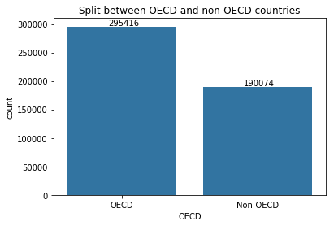

```python
ax = sb.countplot(data = pisa, x = 'OECD', color = sb.color_palette()[0], order = pisa['OECD'].value_counts().index)
plt.title('Split between OECD and non-OECD countries')

for p, label in zip(ax.patches, pisa['OECD'].value_counts().values):
    ax.annotate(label, (p.get_x()+0.30, p.get_height()+2000))

plt.show()
```

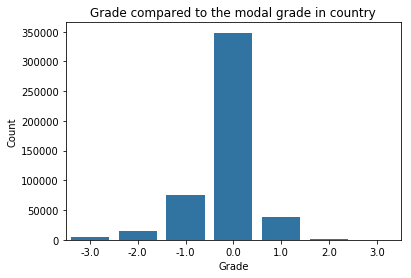

```python
# Grade compared to the modal grade in country
sb.countplot(data = pisa, x = 'GRADE',color = sb.color_palette()[0])
plt.ylabel('Count')
plt.xlabel('Grade')
plt.title('Grade compared to the modal grade in country')
plt.show()
```

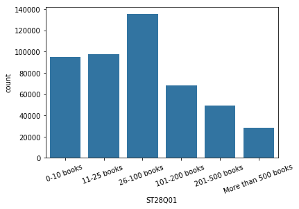

```python
#Number of books at home
books = ['0-10 books ','11-25 books ','26-100 books ','101-200 books ', '201-500 books ', 'More than 500 books']
bookclasses = pd.api.types.CategoricalDtype(ordered = True, categories = books)
pisa['ST28Q01'] = pisa['ST28Q01'].astype(bookclasses)

sb.countplot(data = pisa, x= 'ST28Q01', color = sb.color_palette()[0])
plt.xticks(rotation = 20)
plt.show()
```

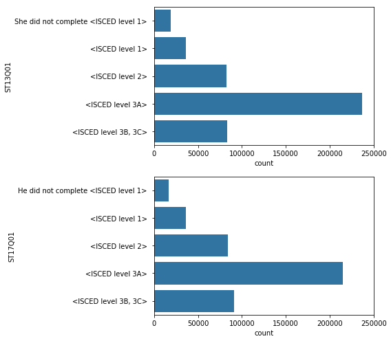

```python
#Is there a difference between the schooling level of the parents  ?

fig = plt.figure(figsize = (8,7))

xticks = np.arange(0,300000,50000)

#Mother's highest schooling distribution
schooling_distribution = ['She did not complete <ISCED level 1> ','<ISCED level 1> ','<ISCED level 2> ','<ISCED level 3A> ','<ISCED level 3B, 3C> ']
schooling = pd.api.types.CategoricalDtype(ordered = True, categories = schooling_distribution)
pisa['ST13Q01'] = pisa['ST13Q01'].astype(schooling)

ax1 = fig.add_subplot(211)
sb.countplot(data = pisa, y ='ST13Q01', color = sb.color_palette()[0])
plt.xticks(xticks,xticks)

# Father's highest schooling distribution
schooling_distribution = ['He did not complete <ISCED level 1> ','<ISCED level 1> ','<ISCED level 2> ','<ISCED level 3A> ','<ISCED level 3B, 3C> ']
schooling = pd.api.types.CategoricalDtype(ordered = True, categories = schooling_distribution)
pisa['ST17Q01'] = pisa['ST17Q01'].astype(schooling)

ax2 = fig.add_subplot(212)
sb.countplot(data = pisa, y ='ST17Q01',color = sb.color_palette()[0])
plt.xticks(xticks,xticks)

plt.tight_layout()
plt.show()
```

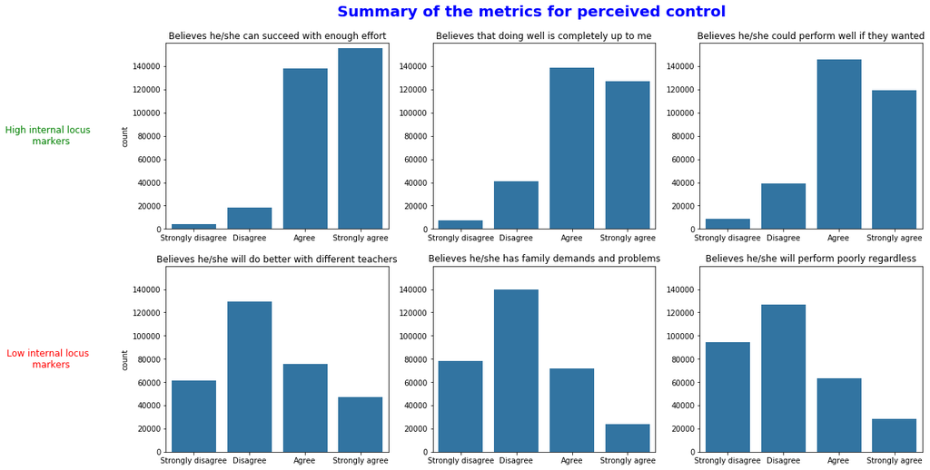

```python
#Perceived control metrics
fig = plt.figure(figsize = (18,10))
agreement = ['Strongly disagree','Disagree','Agree','Strongly agree']
agreement_distribution = pd.api.types.CategoricalDtype(ordered = True, categories = agreement)
pisa['ST43Q01'] = pisa['ST43Q01'].astype(agreement_distribution)
pisa['ST43Q02'] = pisa['ST43Q02'].astype(agreement_distribution)
pisa['ST43Q03'] = pisa['ST43Q03'].astype(agreement_distribution)
pisa['ST43Q04'] = pisa['ST43Q04'].astype(agreement_distribution)
pisa['ST43Q05'] = pisa['ST43Q05'].astype(agreement_distribution)
pisa['ST43Q06'] = pisa['ST43Q06'].astype(agreement_distribution)

yticks = np.arange(0,160000,20000)

#Can Succeed with Enough Effort
ax1 = fig.add_subplot(231)
sb.countplot(data = pisa, x ='ST43Q01',color = sb.color_palette()[0])
plt.title('Believes he/she can succeed with enough effort')
plt.ylim(0,160000)
plt.yticks(yticks)
plt.xlabel('')
ax1.annotate('High internal locus \n markers', xy=(0, 0.5), xytext=(ax1.yaxis.labelpad-100, 0),
                xycoords=ax1.yaxis.label, textcoords='offset points',
                size='large', ha='center', va='center', color = 'green')


#Doing Well is Completely Up to Me
ax2 = fig.add_subplot(232)
sb.countplot(data = pisa, x ='ST43Q02',color = sb.color_palette()[0])
plt.title('Believes that doing well is completely up to me')
plt.ylim(0,160000)
plt.yticks(yticks)
plt.xlabel('')
plt.ylabel('')

#If I Wanted I Could Perform Well
ax5 = fig.add_subplot(233)
sb.countplot(data = pisa, x ='ST43Q05',color = sb.color_palette()[0])
plt.title('Believes he/she could perform well if they wanted')
plt.ylim(0,160000)
plt.yticks(yticks)
plt.xlabel('')
plt.ylabel('')


#Different Teachers
ax4 = fig.add_subplot(234)
sb.countplot(data = pisa, x ='ST43Q04',color = sb.color_palette()[0])
plt.title('Believes he/she will do better with different teachers')
plt.ylim(0,160000)
plt.yticks(yticks)
plt.xlabel('')
ax4.annotate('Low internal locus \n markers', xy=(0, 0.5), xytext=(ax4.yaxis.labelpad-100, 0),
                xycoords=ax4.yaxis.label, textcoords='offset points',
                size='large', ha='center', va='center', color = 'red')


#Family Demands and Problems
ax3 = fig.add_subplot(235)
sb.countplot(data = pisa, x ='ST43Q03',color = sb.color_palette()[0])
plt.title('Believes he/she has family demands and problems')
plt.ylim(0,160000)
plt.yticks(yticks)
plt.xlabel('')
plt.ylabel('')

#Perform Poorly Regardless
ax6 = fig.add_subplot(236)
sb.countplot(data = pisa, x ='ST43Q06',color = sb.color_palette()[0])
plt.title('Believes he/she will perform poorly regardless')
plt.ylim(0,160000)
plt.yticks(yticks)
plt.xlabel('')
plt.ylabel('')

plt.suptitle('Summary of the metrics for perceived control', x = 0.5, y = 0.95, fontsize = 20, fontweight='bold', color = 'blue')
plt.show()
```

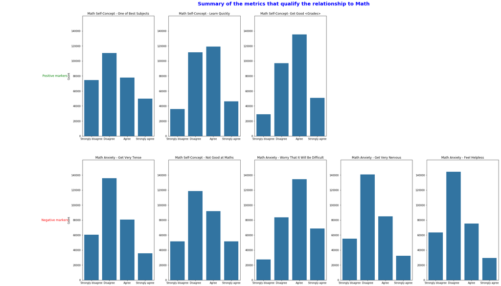

```python
#Relationship with Math
fig = plt.figure(figsize = (30,16))
agreement = ['Strongly disagree','Disagree','Agree','Strongly agree']
agreement_distribution = pd.api.types.CategoricalDtype(ordered = True, categories = agreement)
pisa['ST42Q08'] = pisa['ST42Q08'].astype(agreement_distribution)
pisa['ST42Q07'] = pisa['ST42Q07'].astype(agreement_distribution)
pisa['ST42Q06'] = pisa['ST42Q06'].astype(agreement_distribution)
pisa['ST42Q05'] = pisa['ST42Q05'].astype(agreement_distribution)
pisa['ST42Q04'] = pisa['ST42Q04'].astype(agreement_distribution)
pisa['ST42Q03'] = pisa['ST42Q03'].astype(agreement_distribution)
pisa['ST42Q02'] = pisa['ST42Q02'].astype(agreement_distribution)
pisa['ST42Q01'] = pisa['ST42Q01'].astype(agreement_distribution)

yticks = np.arange(0,160000,20000)


#Math Self-Concept - One of Best Subjects
ax2 = fig.add_subplot(251)
sb.countplot(data = pisa, x ='ST42Q07',color = sb.color_palette()[0])
plt.title('Math Self-Concept - One of Best Subjects')
plt.ylim(0,160000)
plt.yticks(yticks)
plt.xlabel('')
plt.ylabel('Count')
ax2.annotate('Positive markers', xy=(0, 0.5), xytext=(ax2.yaxis.labelpad- 5, 0),
                xycoords=ax2.yaxis.label, textcoords='offset points',
                size='large', ha='right', va='center', color = 'green')

#Math Self-Concept - Learn Quickly
ax5 = fig.add_subplot(252)
sb.countplot(data = pisa, x ='ST42Q06',color = sb.color_palette()[0])
plt.title('Math Self-Concept - Learn Quickly')
plt.ylim(0,160000)
plt.yticks(yticks)
plt.xlabel('')
plt.ylabel('')

#Math Self-Concept- Get Good <Grades>
ax3 = fig.add_subplot(253)
sb.countplot(data = pisa, x ='ST42Q04',color = sb.color_palette()[0])
plt.title('Math Self-Concept- Get Good <Grades>')
plt.ylim(0,160000)
plt.yticks(yticks)
plt.xlabel('')
plt.ylabel('')

#Math Anxiety - Get Very Tense
ax6 = fig.add_subplot(256)
sb.countplot(data = pisa, x ='ST42Q03',color = sb.color_palette()[0])
plt.title('Math Anxiety - Get Very Tense')
plt.ylim(0,160000)
plt.yticks(yticks)
plt.xlabel('')
plt.ylabel('Count')
ax2.annotate('Negative markers', xy=(1.05, 0.5), xytext=(ax6.yaxis.labelpad-5, 0),
                xycoords=ax6.yaxis.label, textcoords='offset points',
                size='large', ha='center', va='center', color = 'red')


#Math Self-Concept - Not Good at Maths
ax6 = fig.add_subplot(257)
sb.countplot(data = pisa, x ='ST42Q02',color = sb.color_palette()[0])
plt.title('Math Self-Concept - Not Good at Maths')
plt.ylim(0,160000)
plt.yticks(yticks)
plt.xlabel('')
plt.ylabel('')

#Math Anxiety - Worry That It Will Be Difficult
ax6 = fig.add_subplot(258)
sb.countplot(data = pisa, x ='ST42Q01',color = sb.color_palette()[0])
plt.title('Math Anxiety - Worry That It Will Be Difficult')
plt.ylim(0,160000)
plt.yticks(yticks)
plt.xlabel('')
plt.ylabel('')

#Math Anxiety - Get Very Nervous
ax4 = fig.add_subplot(259)
sb.countplot(data = pisa, x ='ST42Q05',color = sb.color_palette()[0])
plt.title('Math Anxiety - Get Very Nervous')
plt.ylim(0,160000)
plt.yticks(yticks)
plt.xlabel('')
plt.ylabel('')

##Math Anxiety - Feel Helpless
ax1 = fig.add_subplot(2,5,10)
sb.countplot(data = pisa, x ='ST42Q08',color = sb.color_palette()[0])
plt.title('Math Anxiety - Feel Helpless')
plt.ylim(0,160000)
plt.yticks(yticks)
plt.xlabel('')
plt.ylabel('')

plt.subplots_adjust(left = 0.125,top = 1.05)
plt.suptitle('Summary of the metrics that qualify the relationship to Math', x = 0.5, y = 1.1, fontsize = 20, fontweight='bold', color = 'blue')
plt.show()
```

### <font color = 'blue'>Univariate Assessment

#### <font color = 'red'> Geography </font>

> - There is about 100,000 more students that have been surveyed in OECD countries compared to non-OECD countries. I will have to be careful when comparing the two.

#### <font color = 'red'> Grades </font>

> - Grade distribution compared to the modal grade in all the countries is roughly normal.

#### <font color = 'red'> Parents </font>

> - Both parents have almost the same level of education, with a majority of the parents that have completed ISCED level 3A, 3B, and 3C.

#### <font color = 'red'> Books </font>

> - The number of books owned has a right skewed distribution, with an average of 26-100 books per household.

#### <font color = 'red'> Feelings towards math </font>

> - If we look at the overal metrics that qualify the relationship to Math, there isn't really a trend that we can distinguish. We would need to dig deeper if we wanted to make any statements with respect to this data.

## Bivariate Exploration

[figure not shown]

```python
pisa_mom = pisa.query('ST11Q01 == "Yes"')
pisa_nomom = pisa.query('ST11Q01 == "No"')

fig = plt.figure(figsize = (10,5))

ax1 = fig.add_subplot(121)
ax1 = sb.barplot(x='GRADE', y='GRADE',data=pisa_mom, estimator=lambda x: len(x) / len(pisa_mom) * 100, color = sb.color_palette()[0])
ax1.set(ylabel="Percent")
plt.ylim(0,75)
plt.title('Relative Grade distribution without mother at home')

ax2 = fig.add_subplot(122)
ax2 = sb.barplot(x='GRADE', y='GRADE',data=pisa_nomom, estimator=lambda x: len(x) / len(pisa_nomom) * 100, color = sb.color_palette()[0])
ax2.set(ylabel="Percent")
plt.ylim(0,75)
plt.title('Relative Grade distribution without mother at home')

plt.tight_layout()
plt.show()
```

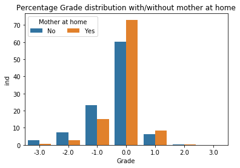

```python
# dataframe (it is used to count the number of students in the groups)
df_new = pisa[["GRADE", "ST11Q01"]]
df_new.reset_index(inplace = True)
df_new.columns=['ind','Grade','Mother\nAt Home']
# count the number of students in each group
df_new_per = df_new.groupby(["Mother\nAt Home","Grade"]).agg({'ind': 'count'})

# groupby ST11Q01 (the first level in the index) and divide by sum
grade_pcts = df_new_per.groupby(level=0).apply(lambda x:
                                                 100 * x / float(x.sum())).reset_index()

# plot
sb.barplot(x='Grade', y='ind' , hue = "Mother\nAt Home", data=grade_pcts);
plt.legend(ncol = 2, title = 'Mother at home' )
plt.title('Percentage Grade distribution with/without mother at home')
plt.show()
```

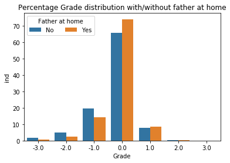

```python
# dataframe (it is used to count the number of students in the groups)
df_new = pisa[["GRADE", "ST11Q02"]]
df_new.reset_index(inplace = True)
df_new.columns=['ind','Grade','Father\nAt Home']
# count the number of students in each group
df_new_per = df_new.groupby(["Father\nAt Home","Grade"]).agg({'ind': 'count'})

# groupby ST11Q02 (the first level in the index) and divide by sum
grade_pcts = df_new_per.groupby(level=0).apply(lambda x:
                                                 100 * x / float(x.sum())).reset_index()

# plot
sb.barplot(x='Grade', y='ind' , hue = "Father\nAt Home", data=grade_pcts);
plt.legend(ncol = 2, title = 'Father at home' )
plt.title('Percentage Grade distribution with/without father at home')
plt.show()
```

```python
agreement_dict = {'Strongly disagree':-2,'Disagree':-1,'Agree':1,'Strongly agree':2}
agreement_dict_r = {'Strongly disagree':2,'Disagree':1,'Agree':-1,'Strongly agree':-2}

#Creat a positive and negative dictionnary for the perceived control markers
positive_columnlist = [['pc_effort','ST43Q01'],
                       ['pc_doingwell','ST43Q02'],
                       ['pc_willtoperform','ST43Q05']]


negative_columnlist =[['pc_family_demands','ST43Q04'],
                      ['pc_different_teachers','ST43Q05'],
                      ['perform_poorly','ST43Q06']]

#map each of the values in a column
for newcolumn,mappedcolumn in positive_columnlist:
    pisa[newcolumn] = pisa[mappedcolumn].map(agreement_dict)

for newcolumn,mappedcolumn in negative_columnlist:
    pisa[newcolumn] = pisa[mappedcolumn].map(agreement_dict_r)
```

```python
pisa.groupby('ST04Q01')['GRADE'].mean()
```

```
ST04Q01
Female   -0.126296
Male     -0.200380
Name: GRADE, dtype: float64
```

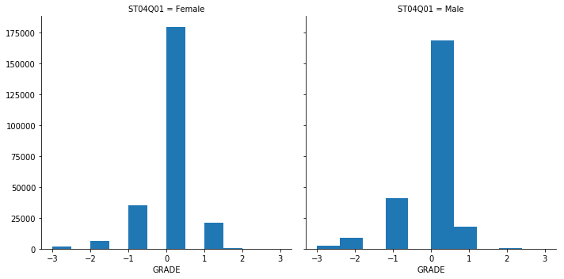

```python
g = sb.FacetGrid(data = pisa, col = 'ST04Q01', size = 5)
g.map(plt.hist,'GRADE')
plt.show()
```

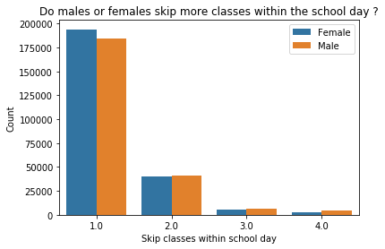

```python
# Do male or female students skip more classes within the school day.
sb.countplot(data = pisa, x ='ST115Q01', hue = 'ST04Q01')
plt.legend(title = '')
plt.ylabel('Count')
plt.xlabel('Skip classes within school day')
plt.title('Do males or females skip more classes within the school day ?')
plt.show()

# Careful since the number of male and female students is not exactly similar, the count is not very significant.
# Will need to transform this into proportions.
```

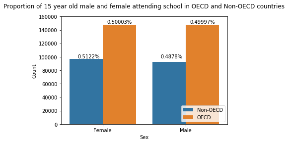

```python
ax = sb.countplot(data = pisa, x = 'ST04Q01', hue = 'OECD')
for p, label in zip(ax.patches, pisa.query('OECD == "OECD"')['ST04Q01'].value_counts().values/pisa.query('OECD == "OECD"')['ST04Q01'].value_counts().values.sum()):
    ax.annotate('{:.5f}%'.format(label), (p.get_x()+0.45, 150000))
for p, label in zip(ax.patches, pisa.query('OECD == "Non-OECD"')['ST04Q01'].value_counts().values/pisa.query('OECD == "Non-OECD"')['ST04Q01'].value_counts().values.sum()):
    ax.annotate('{:.4f}%'.format(label), (p.get_x()+0.10, 98000))
plt.xlabel('Sex')
plt.ylabel('Count')
plt.ylim(0,160000)
plt.title('Proportion of 15 year old male and female attending school in OECD and Non-OECD countries')
ax = plt.gca()
ttl = ax.title
ttl.set_position([.5, 1.05])
plt.legend(loc = 4)
plt.show()
```

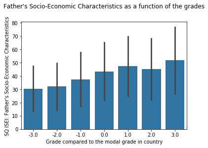

```python
sb.barplot(data = pisa,x = 'GRADE', y='BFMJ2', ci = 'sd', color = sb.color_palette()[0])
plt.title('Father\'s Socio-Economic Characteristics as a function of the grades',loc ='center')
plt.xlabel('Grade compared to the modal grade in country')
plt.ylabel('SQ ISEI: Father\'s Socio-Economic Characteristics')
ax = plt.gca()
ttl = ax.title
ttl.set_position([.5, 1.1])
plt.show()
```

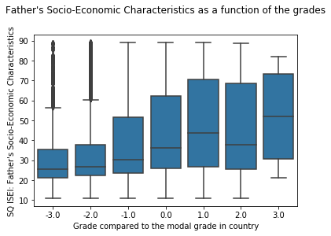

```python
sb.boxplot(data = pisa,x = 'GRADE', y='BFMJ2', color = sb.color_palette()[0])
plt.title('Father\'s Socio-Economic Characteristics as a function of the grades',loc ='center')
plt.xlabel('Grade compared to the modal grade in country')
plt.ylabel('SQ ISEI: Father\'s Socio-Economic Characteristics')
ax = plt.gca()
ttl = ax.title
ttl.set_position([.5, 1.1])
plt.show()
```

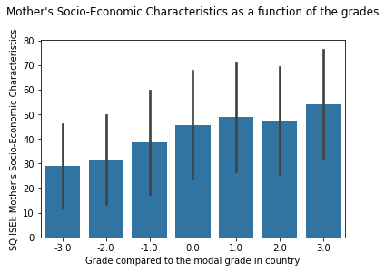

```python
sb.barplot(data = pisa,x = 'GRADE', y='BMMJ1', color = sb.color_palette()[0], ci = 'sd')
plt.title('Mother\'s Socio-Economic Characteristics as a function of the grades',loc ='center')
plt.xlabel('Grade compared to the modal grade in country')
plt.ylabel('SQ ISEI: Mother\'s Socio-Economic Characteristics')
ax = plt.gca()
ttl = ax.title
ttl.set_position([.5, 1.1])
plt.show()
```

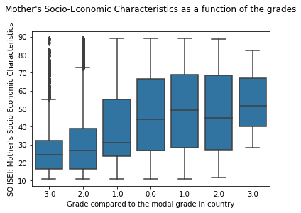

```python
sb.boxplot(data = pisa,x = 'GRADE', y='BMMJ1', color = sb.color_palette()[0])
plt.title('Mother\'s Socio-Economic Characteristics as a function of the grades',loc ='center')
plt.xlabel('Grade compared to the modal grade in country')
plt.ylabel('SQ ISEI: Mother\'s Socio-Economic Characteristics')
ax = plt.gca()
ttl = ax.title
ttl.set_position([.5, 1.1])
plt.show()
```

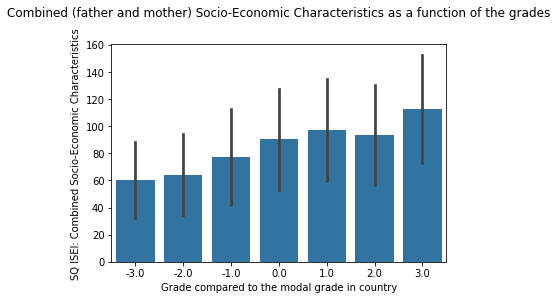

```python
pisa['SQISEI_comb'] = pisa['BFMJ2'] + pisa['BMMJ1']
sb.barplot(data = pisa,x = 'GRADE', y='SQISEI_comb', color = sb.color_palette()[0], ci = 'sd')
plt.title('Combined (father and mother) Socio-Economic Characteristics as a function of the grades',loc ='center')
plt.xlabel('Grade compared to the modal grade in country')
plt.ylabel('SQ ISEI: Combined Socio-Economic Characteristics')
ax = plt.gca()
ttl = ax.title
ttl.set_position([.5, 1.1])
plt.show()
```

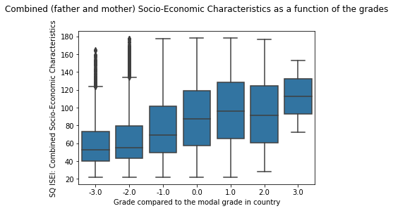

```python
pisa['SQISEI_comb'] = pisa['BFMJ2'] + pisa['BMMJ1']
sb.boxplot(data = pisa,x = 'GRADE', y='SQISEI_comb', color = sb.color_palette()[0])
plt.title('Combined (father and mother) Socio-Economic Characteristics as a function of the grades',loc ='center')
plt.xlabel('Grade compared to the modal grade in country')
plt.ylabel('SQ ISEI: Combined Socio-Economic Characteristics')
ax = plt.gca()
ttl = ax.title
ttl.set_position([.5, 1.1])
plt.show()
```

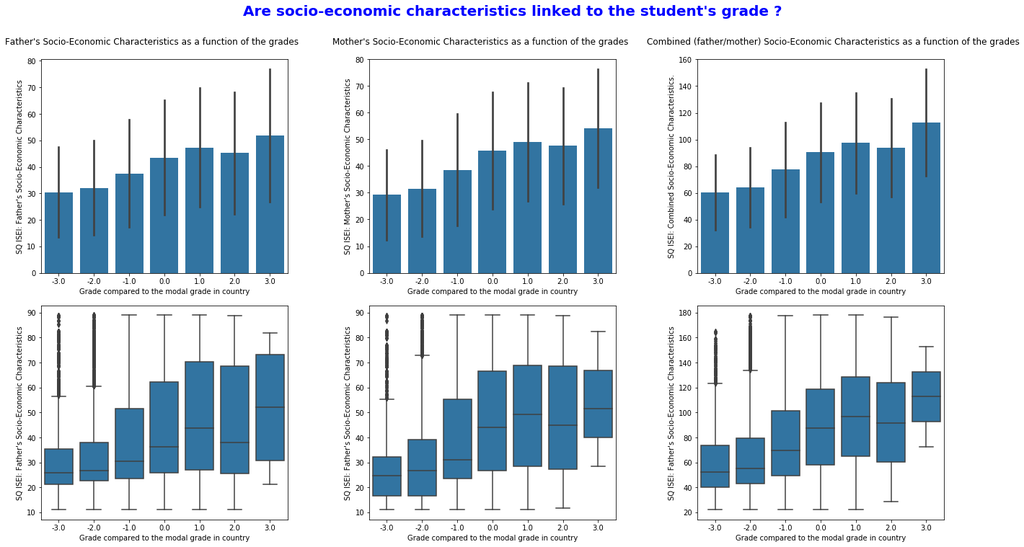

```python
fig = plt.figure(figsize = (20,10))

ax1 = fig.add_subplot(231)
sb.barplot(data = pisa,x = 'GRADE', y='BFMJ2', ci = 'sd', color = sb.color_palette()[0])
plt.title('Father\'s Socio-Economic Characteristics as a function of the grades',loc ='center')
plt.xlabel('Grade compared to the modal grade in country')
plt.ylabel('SQ ISEI: Father\'s Socio-Economic Characteristics')
ttl = ax1.title
ttl.set_position([.45, 1.05])

ax2 = fig.add_subplot(232)
sb.barplot(data = pisa,x = 'GRADE', y='BMMJ1', color = sb.color_palette()[0], ci = 'sd')
plt.title('Mother\'s Socio-Economic Characteristics as a function of the grades',loc ='center')
plt.xlabel('Grade compared to the modal grade in country')
plt.ylabel('SQ ISEI: Mother\'s Socio-Economic Characteristics')
ttl = ax2.title
ttl.set_position([.45, 1.05])

ax3 = fig.add_subplot(233)
sb.barplot(data = pisa,x = 'GRADE', y='SQISEI_comb', color = sb.color_palette()[0], ci = 'sd')
plt.title('Combined (father/mother) Socio-Economic Characteristics as a function of the grades',loc ='center')
plt.xlabel('Grade compared to the modal grade in country')
plt.ylabel('SQ ISEI: Combined Socio-Economic Characteristics.')
ax = plt.gca()
ttl = ax.title
ttl.set_position([.55, 1.05])

ax4 = fig.add_subplot(234)
sb.boxplot(data = pisa,x = 'GRADE', y='BFMJ2', color = sb.color_palette()[0])
plt.xlabel('Grade compared to the modal grade in country')
plt.ylabel('SQ ISEI: Father\'s Socio-Economic Characteristics')

ax5 = fig.add_subplot(235)
sb.boxplot(data = pisa,x = 'GRADE', y='BMMJ1', color = sb.color_palette()[0])
plt.xlabel('Grade compared to the modal grade in country')
plt.ylabel('SQ ISEI: Father\'s Socio-Economic Characteristics')

ax6 = fig.add_subplot(236)
sb.boxplot(data = pisa,x = 'GRADE', y='SQISEI_comb', color = sb.color_palette()[0])
plt.xlabel('Grade compared to the modal grade in country')
plt.ylabel('SQ ISEI: Father\'s Socio-Economic Characteristics')

plt.suptitle('Are socio-economic characteristics linked to the student\'s grade ?', x = 0.5, y = 1.05, fontsize = 20, fontweight='bold', color = 'blue')
plt.tight_layout()
plt.show()
```

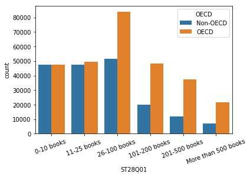

```python
#Number of books at home (absolute count)
books = ['0-10 books ','11-25 books ','26-100 books ','101-200 books ', '201-500 books ', 'More than 500 books']
bookclasses = pd.api.types.CategoricalDtype(ordered = True, categories = books)
pisa['ST28Q01'] = pisa['ST28Q01'].astype(bookclasses)

sb.countplot(data = pisa, x= 'ST28Q01', hue  = 'OECD')
plt.xticks(rotation = 20)
plt.show()
```

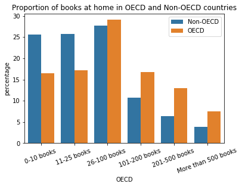

```python
#Number of books at home
pisa_OECD = pisa.groupby(['OECD'],sort = False)
books_counts = pisa_OECD.ST28Q01.value_counts(normalize = True, sort = False)
books_oecd = [{'OECD': OECD, 'ST28Q01':ST28Q01, 'percentage': percentage*100} for (ST28Q01,OECD), percentage in dict(books_counts).items()]

books_oecd_df = pd.DataFrame(books_oecd)

sb.barplot(data = books_oecd_df, x ='OECD', y = 'percentage', hue = 'ST28Q01', order = books)
plt.xticks(rotation = 20)
plt.legend(title = '')
plt.title('Proportion of books at home in OECD and Non-OECD countries')
plt.show()
```

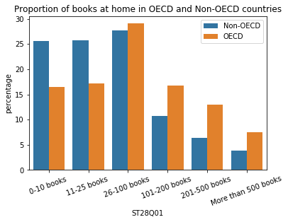

```python
pisa_OECD = pisa.groupby(['OECD'],sort = False)
books_counts = pisa_OECD.ST28Q01.value_counts(normalize = True, sort = False)
books_oecd = [{'OECD': OECD, 'ST28Q01':ST28Q01, 'percentage': percentage*100} for (OECD,ST28Q01), percentage in dict(books_counts).items()]

books_oecd_df = pd.DataFrame(books_oecd)

sb.barplot(data = books_oecd_df, x ='ST28Q01', y = 'percentage', hue = 'OECD', order = books)
plt.xticks(rotation = 20)
plt.legend(title = '')
plt.title('Proportion of books at home in OECD and Non-OECD countries')
plt.show()
```

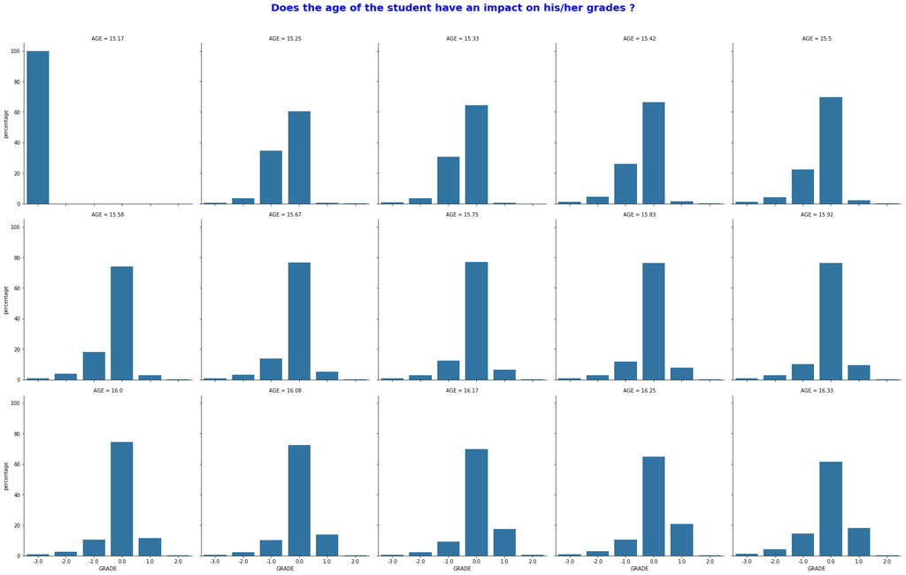

```python
# Does the age of the student matter in the
#Note we are taking into account the months
pisa_age = pisa.groupby(['AGE'],sort = False)
grade_age_counts = pisa_age.GRADE.value_counts(normalize = True, sort = False)
grade_age = [{'AGE': AGE, 'GRADE':GRADE, 'percentage': percentage*100} for (AGE,GRADE), percentage in dict(grade_age_counts).items()]

grade_age_df = pd.DataFrame(grade_age)

g = sb.FacetGrid(data = grade_age_df, col = 'AGE', size = 5, col_wrap = 5)
g.map(sb.barplot,'GRADE', 'percentage')
plt.suptitle('Does the age of the student have an impact on his/her grades ?', x = 0.5, y = 1.05, fontsize = 20, fontweight='bold', color = 'blue')
plt.tight_layout()
plt.show()
```

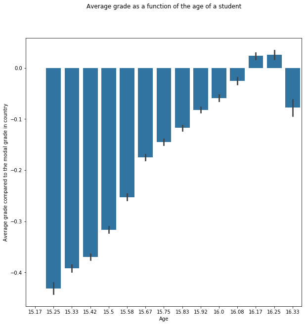

```python
plt.figure(figsize=(10,10))
sb.barplot(data = pisa,x = 'AGE', y='GRADE', color = sb.color_palette()[0])
plt.title('Average grade as a function of the age of a student',loc ='center')
plt.ylabel('Average grade compared to the modal grade in country')
plt.xlabel('Age')
ax = plt.gca()
ttl = ax.title
ttl.set_position([.5, 1.1])
plt.show()
```

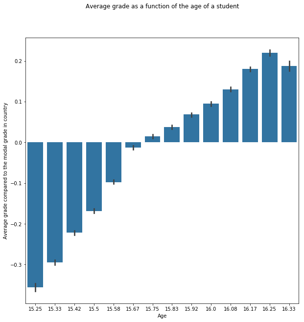

```python
pisa_no_repeat = pisa.query('REPEAT == "Did not repeat a <grade>"')

plt.figure(figsize=(10,10))
sb.barplot(data = pisa_no_repeat,x = 'AGE', y='GRADE', color = sb.color_palette()[0])
plt.title('Average grade as a function of the age of a student',loc ='center')
plt.ylabel('Average grade compared to the modal grade in country')
plt.xlabel('Age')
ax = plt.gca()
ttl = ax.title
ttl.set_position([.5, 1.1])
plt.show()
```

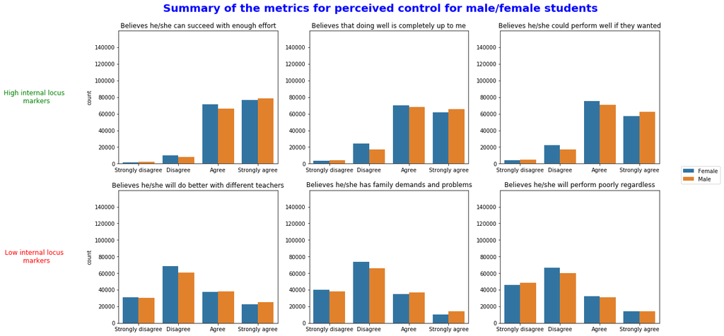

```python
#Perceived control metrics
fig = plt.figure(figsize = (18,10))
agreement = ['Strongly disagree','Disagree','Agree','Strongly agree']
agreement_distribution = pd.api.types.CategoricalDtype(ordered = True, categories = agreement)
pisa['ST43Q01'] = pisa['ST43Q01'].astype(agreement_distribution)
pisa['ST43Q02'] = pisa['ST43Q02'].astype(agreement_distribution)
pisa['ST43Q03'] = pisa['ST43Q03'].astype(agreement_distribution)
pisa['ST43Q04'] = pisa['ST43Q04'].astype(agreement_distribution)
pisa['ST43Q05'] = pisa['ST43Q05'].astype(agreement_distribution)
pisa['ST43Q06'] = pisa['ST43Q06'].astype(agreement_distribution)

yticks = np.arange(0,160000,20000)

#Can Succeed with Enough Effort
ax1 = fig.add_subplot(231)
sb.countplot(data = pisa, x ='ST43Q01', hue = 'ST04Q01')
plt.title('Believes he/she can succeed with enough effort')
plt.ylim(0,160000)
ax1.get_legend().remove()
plt.yticks(yticks)
plt.xlabel('')
ax1.annotate('High internal locus \n markers', xy=(0, 0.5), xytext=(ax1.yaxis.labelpad-100, 0),
                xycoords=ax1.yaxis.label, textcoords='offset points',
                size='large', ha='center', va='center', color = 'green')

#Doing Well is Completely Up to Me
ax2 = fig.add_subplot(232)
sb.countplot(data = pisa, x ='ST43Q02',hue = 'ST04Q01')
plt.title('Believes that doing well is completely up to me')
plt.ylim(0,160000)
ax2.get_legend().remove()
plt.yticks(yticks)
plt.xlabel('')
plt.ylabel('')

#If I Wanted I Could Perform Well
ax3 = fig.add_subplot(233)
sb.countplot(data = pisa, x ='ST43Q05',hue = 'ST04Q01')
plt.title('Believes he/she could perform well if they wanted')
plt.ylim(0,160000)
plt.legend(bbox_to_anchor=(1.4, 0))
plt.yticks(yticks)
plt.xlabel('')
plt.ylabel('')


#Different Teachers
ax4 = fig.add_subplot(234)
sb.countplot(data = pisa, x ='ST43Q04',hue = 'ST04Q01')
plt.title('Believes he/she will do better with different teachers')
plt.ylim(0,160000)
ax4.get_legend().remove()
plt.yticks(yticks)
plt.xlabel('')
ax4.annotate('Low internal locus \n markers', xy=(0, 0.5), xytext=(ax4.yaxis.labelpad-100, 0),
                xycoords=ax4.yaxis.label, textcoords='offset points',
                size='large', ha='center', va='center', color = 'red')

#Family Demands and Problems
ax5 = fig.add_subplot(235)
sb.countplot(data = pisa, x ='ST43Q03',hue = 'ST04Q01')
plt.title('Believes he/she has family demands and problems')
plt.ylim(0,160000)
ax5.get_legend().remove()
plt.yticks(yticks)
plt.xlabel('')
plt.ylabel('')

#Perform Poorly Regardless
ax6 = fig.add_subplot(236)
sb.countplot(data = pisa, x ='ST43Q06',hue = 'ST04Q01')
plt.title('Believes he/she will perform poorly regardless')
plt.ylim(0,160000)
ax6.get_legend().remove()
plt.yticks(yticks)
plt.xlabel('')
plt.ylabel('')

plt.suptitle('Summary of the metrics for perceived control for male/female students', x = 0.5, y = 0.95, fontsize = 20, fontweight='bold', color = 'blue')
plt.show()
```